# final project team 5

2022-12-12

# Investigation in DC crime trend 2016-2021

Professor: Dr. Farhana Faruqe

DATS-6101: Introduction to Data Science

Member: Xuanyu Chen, Yuchuan Feng, Ore Asaba, Kentaro Osawa, Adewale Maye

# Some EDA

## Heat map

There are two fields in the data which provide the description of the crime incident. The first, primary description provides a broad category of the crime type and the second provides more detailed information about the first. We use the primary description to categorize different crime types.

The data contains 30 crime types; not all of which are mutually exclusive. We can combine two or more similar categories into one to reduce this number and make the analysis a bit more manageable.

```
## # A tibble: 10 × 2
##    crime      count
##    <fct>      <int>
##  1 ASSAULT    44146
##  2 VIOLENT    34409
##  3 TRAFFIC    19989
##  4 NONVIOLENT 13291
##  5 DRUG       12825
##  6 OTHERS     12178
##  7 THEFT      10826
##  8 SEX         3984
##  9 FRAUD        671
## 10 <NA>          12
```

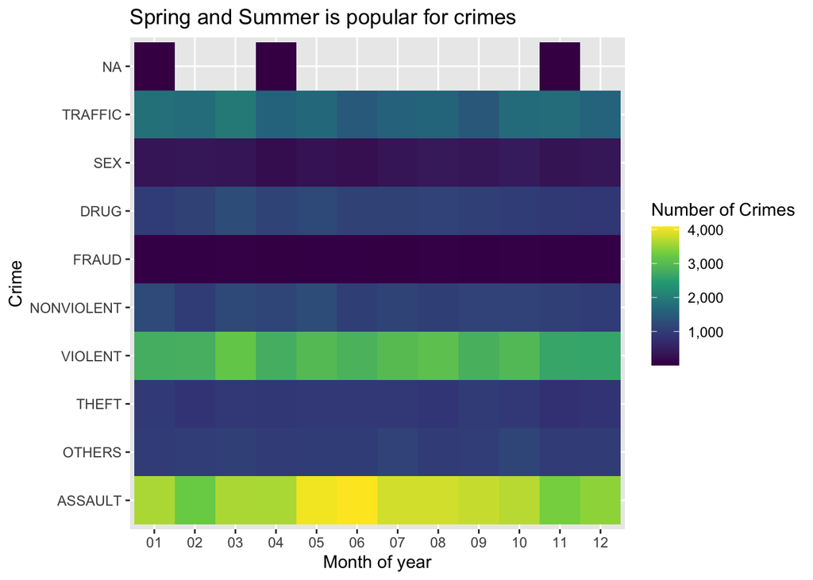

A quick look at the heat map shows that most of crime happens at the spring and summer.

```
## # A tibble: 16,768 × 3
## # Groups:   crime [10]
##    crime      Arrest_Date count
##    <fct>      <date>      <int>
##  1 ASSAULT    2020-06-01    274
##  2 NONVIOLENT 2017-01-20    234
##  3 ASSAULT    2021-01-06     65
##  4 VIOLENT    2017-08-23     47
##  5 ASSAULT    2016-01-01     46
##  6 ASSAULT    2016-10-30     45
##  7 VIOLENT    2016-04-21     44
##  8 ASSAULT    2017-01-01     42
##  9 ASSAULT    2016-06-25     41
## 10 ASSAULT    2017-04-29     41
## # … with 16,758 more rows
```

By ordering this, we can see from all the data, assault happens a lot times at 2020-06-01 and also nonviolent happens much higher at 2017-01-20 than the other dates.

```
## # A tibble: 2,192 × 1
##    Arrest_Date
##    <date>
##  1 2016-01-01
##  2 2016-01-02
##  3 2016-01-03
##  4 2016-01-04
##  5 2016-01-05
##  6 2016-01-06
##  7 2016-01-07
##  8 2016-01-08
##  9 2016-01-09
## 10 2016-01-10
## # … with 2,182 more rows
```

```
## # A tibble: 4 × 2
##   crime_type count
##   <fct>      <int>
## 1 <NA>          12
## 2 OTHERS     12178
## 3 NONVIOLENT 57602
## 4 VIOLENT    82539
```

Violent crime is far more than nonviolent crime.

#### Class by seasons

Our visualization exercise showed that there is considerable variation in crime incidents with respect to the time of the year. To use the month variable effectively, we can combine the similar months to form a new variable that reflects the changes in crime incidents with seasons.

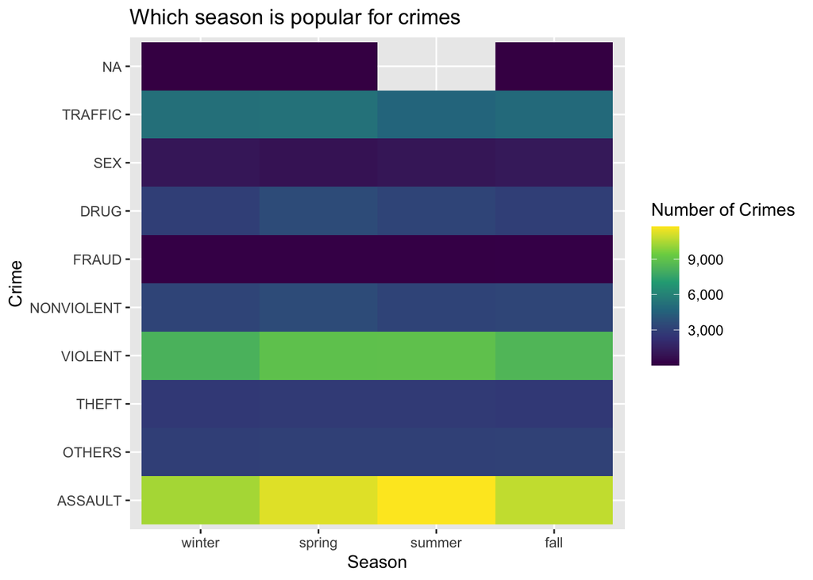

This chart is more clear than the month chart that summer has the most crime.

# Model

## Log-linear model

We calculated $\lambda$ without considering the effects of “Month”, “Weekday” and “District” in the midterm project. For final project, We will check these effects on the counts of each major crime using a Log-linear model.

In a Log-linear model, response variable is a count of some occurrence that follows a Poisson distribution, and explanatory variables are categorical variables. The expected counts $\mu_{ij}$ is modeled as follows:
$$\log(\mu_{ij})=\lambda + \lambda^A_i +
\lambda^B_j + \lambda^{AB}_{ij},$$
where $\lambda$ is a ground effect, $\lambda^A_i$ is the main effect of $i$ th level of A, and $\lambda^{AB}_{ij}$ is the interaction effect of $i$ th level of A and $j$ th level of B (if any) (https://online.stat.psu.edu/stat504/lesson/10).

# Method

First, We divided the data into two prats: pre-COVID (2016-2019) and post-COVID (2020-2021). Then, each major crime case was classified by “District” and “Weekend”. “District” has five levels (1D, 2D, 3D, 4D, 5D), and “Weekend” has two levels (0 (stands for weekday), 1 (stands for weekend)). DC area are divided by seven police districts, but We excluded sixth and seventh districts because these districts have a very low crime rate, which makes the analysis difficult.

We modeled the relationship between the counts of each major crime and categorical variables (“District” and “Weekend”) using four independence models and the saturated model:
$${\rm{Model \ 1:}} \
\log(\mu_{ij})=\lambda.$$
$${\rm{Model
\ 2:}} \ \log(\mu_{ij})=\lambda + \lambda^{District}_i.$$
$${\rm{Model \ 3:}} \ \log(\mu_{ij})=\lambda +
\lambda^{Weekend}_j.$$
$${\rm{Model \
4:}} \ \log(\mu_{ij})=\lambda + \lambda^{District}_i +
\lambda^{Weekend}_j.$$
$${\rm{Model \
5:}} \ \log(\mu_{ij})=\lambda + \lambda^{District}_i +
\lambda^{Weekend}_j + \lambda^{District,Weekend}_{ij}.$$

# Model Evaluation

## Simple Assault

The two-way tables for “Simple Assault” are as follows.

```
##         Weekend
## District   0   1
##       1D 154 111
##       2D 286 250
##       3D 255 227
##       4D 301 195
##       5D 100  43
```

```
##         Weekend
## District   0   1
##       1D  44  31
##       2D 111  67
##       3D  96  51
##       4D 103  78
##       5D  32  22
```

### Summary of the models

#### pre-COVID models

```
##
## Call:
## glm(formula = Count ~ 1, family = poisson, data = DF_preCOVID_SA)
##
## Deviance Residuals:
##     Min       1Q   Median       3Q      Max
## -13.024   -5.488    1.321    4.229    7.242
##
## Coefficients:
##             Estimate Std. Error z value Pr(>|z|)
## (Intercept)  5.25854    0.02281   230.5   <2e-16 ***
## ---
## Signif. codes:  0 '***' 0.001 '**' 0.01 '*' 0.05 '.' 0.1 ' ' 1
##
## (Dispersion parameter for poisson family taken to be 1)
##
##     Null deviance: 404.66  on 9  degrees of freedom
## Residual deviance: 404.66  on 9  degrees of freedom
## AIC: 476.29
##
## Number of Fisher Scoring iterations: 4
```

```
##
## Call:
## glm(formula = Count ~ District, family = poisson, data = DF_preCOVID_SA)
##
## Deviance Residuals:
##      22       47       72       99      123      144      169      194
##  1.8204   1.0875   0.8933   3.2552   3.1772  -1.9221  -1.1122  -0.9108
##     216      240
## -3.4975  -3.6427
##
## Coefficients:
##             Estimate Std. Error z value Pr(>|z|)
## (Intercept)  4.88658    0.06143  79.548  < 2e-16 ***
## District2D   0.70440    0.07509   9.380  < 2e-16 ***
## District3D   0.59821    0.07647   7.822 5.18e-15 ***
## District4D   0.62685    0.07609   8.238  < 2e-16 ***
## District5D  -0.61689    0.10376  -5.945 2.76e-09 ***
## ---
## Signif. codes:  0 '***' 0.001 '**' 0.01 '*' 0.05 '.' 0.1 ' ' 1
##
## (Dispersion parameter for poisson family taken to be 1)
##
##     Null deviance: 404.660  on 9  degrees of freedom
## Residual deviance:  57.248  on 5  degrees of freedom
## AIC: 136.88
##
## Number of Fisher Scoring iterations: 4
```

```
##
## Call:
## glm(formula = Count ~ Weekend, family = poisson, data = DF_preCOVID_SA)
##
## Deviance Residuals:
##     Min       1Q   Median       3Q      Max
## -11.342   -4.613    2.305    4.487    6.128
##
## Coefficients:
##             Estimate Std. Error z value Pr(>|z|)
## (Intercept)  5.38998    0.03021 178.441  < 2e-16 ***
## Weekend1    -0.28283    0.04608  -6.138 8.34e-10 ***
## ---
## Signif. codes:  0 '***' 0.001 '**' 0.01 '*' 0.05 '.' 0.1 ' ' 1
##
## (Dispersion parameter for poisson family taken to be 1)
##
##     Null deviance: 404.66  on 9  degrees of freedom
## Residual deviance: 366.60  on 8  degrees of freedom
## AIC: 440.23
##
## Number of Fisher Scoring iterations: 4
```

```
##
## Call:
## glm(formula = Count ~ District + Weekend, family = poisson, data = DF_preCOVID_SA)
##
## Deviance Residuals:
##      22       47       72       99      123      144      169      194
##  0.2341  -1.1362  -1.2125   1.0686   1.9732  -0.2716   1.2768   1.3584
##     216      240
## -1.2622  -2.4899
##
## Coefficients:
##             Estimate Std. Error z value Pr(>|z|)
## (Intercept)  5.01803    0.06454  77.748  < 2e-16 ***
## District2D   0.70440    0.07509   9.380  < 2e-16 ***
## District3D   0.59821    0.07647   7.822 5.18e-15 ***
## District4D   0.62685    0.07609   8.238  < 2e-16 ***
## District5D  -0.61689    0.10376  -5.945 2.76e-09 ***
## Weekend1    -0.28283    0.04608  -6.138 8.35e-10 ***
## ---
## Signif. codes:  0 '***' 0.001 '**' 0.01 '*' 0.05 '.' 0.1 ' ' 1
##
## (Dispersion parameter for poisson family taken to be 1)
##
##     Null deviance: 404.660  on 9  degrees of freedom
## Residual deviance:  19.193  on 4  degrees of freedom
## AIC: 100.82
##
## Number of Fisher Scoring iterations: 4
```

```
##
## Call:
## glm(formula = Count ~ District * Weekend, family = poisson, data = DF_preCOVID_SA)
##
## Deviance Residuals:
##  [1]  0  0  0  0  0  0  0  0  0  0
##
## Coefficients:
##                     Estimate Std. Error z value Pr(>|z|)
## (Intercept)          5.03695    0.08058  62.507  < 2e-16 ***
## District2D           0.61904    0.09995   6.193 5.88e-10 ***
## District3D           0.50431    0.10205   4.942 7.75e-07 ***
## District4D           0.67016    0.09907   6.764 1.34e-11 ***
## District5D          -0.43178    0.12843  -3.362 0.000774 ***
## Weekend1            -0.32742    0.12451  -2.630 0.008546 **
## District2D:Weekend1  0.19289    0.15165   1.272 0.203403
## District3D:Weekend1  0.21111    0.15437   1.368 0.171446
## District4D:Weekend1 -0.10669    0.15477  -0.689 0.490606
## District5D:Weekend1 -0.51655    0.22081  -2.339 0.019320 *
## ---
## Signif. codes:  0 '***' 0.001 '**' 0.01 '*' 0.05 '.' 0.1 ' ' 1
##
## (Dispersion parameter for poisson family taken to be 1)
##
##     Null deviance: 4.0466e+02  on 9  degrees of freedom
## Residual deviance: 6.8834e-15  on 0  degrees of freedom
## AIC: 89.628
##
## Number of Fisher Scoring iterations: 2
```

#### post-COVID models

```
##
## Call:
## glm(formula = Count ~ 1, family = poisson, data = DF_postCOVID_SA)
##
## Deviance Residuals:
##     Min       1Q   Median       3Q      Max
## -6.0299  -3.9292  -0.5948   3.2807   5.3838
##
## Coefficients:
##             Estimate Std. Error z value Pr(>|z|)
## (Intercept)  4.15104    0.03968   104.6   <2e-16 ***
## ---
## Signif. codes:  0 '***' 0.001 '**' 0.01 '*' 0.05 '.' 0.1 ' ' 1
##
## (Dispersion parameter for poisson family taken to be 1)
##
##     Null deviance: 152.65  on 9  degrees of freedom
## Residual deviance: 152.65  on 9  degrees of freedom
## AIC: 213.24
##
## Number of Fisher Scoring iterations: 4
```

```
##
## Call:
## glm(formula = Count ~ District, family = poisson, data = DF_postCOVID_SA)
##
## Deviance Residuals:
##      17       43       67       90      112      129      149      166
##  1.0328   2.2446   2.5052   1.2853   0.9346  -1.0946  -2.4396  -2.7790
##     184      198
## -1.3461  -0.9945
##
## Coefficients:
##             Estimate Std. Error z value Pr(>|z|)
## (Intercept)   3.6243     0.1155  31.388  < 2e-16 ***
## District2D    0.8643     0.1377   6.278 3.42e-10 ***
## District3D    0.6729     0.1419   4.742 2.11e-06 ***
## District4D    0.8810     0.1373   6.415 1.40e-10 ***
## District5D   -0.3285     0.1785  -1.841   0.0657 .
## ---
## Signif. codes:  0 '***' 0.001 '**' 0.01 '*' 0.05 '.' 0.1 ' ' 1
##
## (Dispersion parameter for poisson family taken to be 1)
##
##     Null deviance: 152.655  on 9  degrees of freedom
## Residual deviance:  32.581  on 5  degrees of freedom
## AIC: 101.17
##
## Number of Fisher Scoring iterations: 4
```

```
##
## Call:
## glm(formula = Count ~ Weekend, family = poisson, data = DF_postCOVID_SA)
##
## Deviance Residuals:
##    Min      1Q  Median      3Q     Max
## -5.834  -3.802   1.115   2.673   3.687
##
## Coefficients:
##             Estimate Std. Error z value Pr(>|z|)
## (Intercept)  4.34640    0.05090  85.394  < 2e-16 ***
## Weekend1    -0.43838    0.08128  -5.393 6.91e-08 ***
## ---
## Signif. codes:  0 '***' 0.001 '**' 0.01 '*' 0.05 '.' 0.1 ' ' 1
##
## (Dispersion parameter for poisson family taken to be 1)
##
##     Null deviance: 152.65  on 9  degrees of freedom
## Residual deviance: 122.86  on 8  degrees of freedom
## AIC: 185.45
##
## Number of Fisher Scoring iterations: 4
```

```
##
## Call:
## glm(formula = Count ~ District + Weekend, family = poisson, data = DF_postCOVID_SA)
##
## Deviance Residuals:
##      17       43       67       90      112      129      149      166
## -0.2369   0.2679   0.6943  -0.6771  -0.1446   0.2907  -0.3372  -0.8926
##     184      198
##  0.8207   0.1782
##
## Coefficients:
##             Estimate Std. Error z value Pr(>|z|)
## (Intercept)  3.81970    0.11979  31.887  < 2e-16 ***
## District2D   0.86430    0.13766   6.278 3.42e-10 ***
## District3D   0.67294    0.14190   4.742 2.11e-06 ***
## District4D   0.88101    0.13732   6.416 1.40e-10 ***
## District5D  -0.32850    0.17847  -1.841   0.0657 .
## Weekend1    -0.43838    0.08128  -5.393 6.91e-08 ***
## ---
## Signif. codes:  0 '***' 0.001 '**' 0.01 '*' 0.05 '.' 0.1 ' ' 1
##
## (Dispersion parameter for poisson family taken to be 1)
##
##     Null deviance: 152.6545  on 9  degrees of freedom
## Residual deviance:   2.7894  on 4  degrees of freedom
## AIC: 73.38
##
## Number of Fisher Scoring iterations: 3
```

```
##
## Call:
## glm(formula = Count ~ District * Weekend, family = poisson, data = DF_postCOVID_SA)
##
## Deviance Residuals:
##  [1]  0  0  0  0  0  0  0  0  0  0
##
## Coefficients:
##                     Estimate Std. Error z value Pr(>|z|)
## (Intercept)          3.78419    0.15076  25.101  < 2e-16 ***
## District2D           0.92534    0.17815   5.194 2.06e-07 ***
## District3D           0.78016    0.18205   4.285 1.82e-05 ***
## District4D           0.85054    0.18010   4.723 2.33e-06 ***
## District5D          -0.31845    0.23233  -1.371    0.170
## Weekend1            -0.35020    0.23449  -1.493    0.135
## District2D:Weekend1 -0.15464    0.28093  -0.550    0.582
## District3D:Weekend1 -0.28232    0.29156  -0.968    0.333
## District4D:Weekend1  0.07218    0.27841   0.259    0.795
## District5D:Weekend1 -0.02449    0.36289  -0.067    0.946
## ---
## Signif. codes:  0 '***' 0.001 '**' 0.01 '*' 0.05 '.' 0.1 ' ' 1
##
## (Dispersion parameter for poisson family taken to be 1)
##
##     Null deviance:  1.5265e+02  on 9  degrees of freedom
## Residual deviance: -1.6875e-14  on 0  degrees of freedom
## AIC: 78.59
##
## Number of Fisher Scoring iterations: 3
```

### Deviance

We used “residual deviance” to test the below hypothesis at a significance level $\alpha=0.05$:
$$H_0: \ \rm{Reduced \ model \ is \
true.}$$
$$H_1: \ \rm{Satureated \
model \ (Model \ 5) \ is \ true.}$$
“residual deviance” is the difference between the deviance of the model and that of the saturated model. According to The Pennsylvania State University website (https://online.stat.psu.edu/stat504/lesson/6/6.3/6.3.4), “residual deviance” follows a chi-square distribution with the model’s degrees of freedom. Therefore, to test the hypothesis, I calculated p-values.

**pre-COVID**  
The null hypothesis is rejected for all models.

```
## [1] 1.387893e-81
```

```
## [1] 4.495019e-11
```

```
## [1] 2.577896e-74
```

```
## [1] 0.0007201423
```

**post-COVID**  
The null hypothesis is not rejected for Model 4.

```
## [1] 2.485053e-28
```

```
## [1] 4.558496e-06
```

```
## [1] 8.491105e-23
```

```
## [1] 0.593663
```

### AIC and BIC

Each model’s AIC and BIC was as follows.

**pre-COVID**

Model 5 is the best in terms of both AIC and BIC

```
## [1] "AIC"
```

```
## [1] 476.2873
```

```
## [1] 136.8757
```

```
## [1] 440.2323
```

```
## [1] 100.8208
```

```
## [1] 89.62757
```

```
## [1] "BIC"
```

```
## [1] 476.5899
```

```
## [1] 138.3887
```

```
## [1] 440.8375
```

```
## [1] 102.6363
```

```
## [1] 92.65342
```

**post-COVID**

Model 4 is the best in terms of both AIC and BIC.

```
## [1] "AIC"
```

```
## [1] 213.2448
```

```
## [1] 101.1708
```

```
## [1] 185.4536
```

```
## [1] 73.37966
```

```
## [1] 78.59026
```

```
## [1] "BIC"
```

```
## [1] 213.5474
```

```
## [1] 102.6837
```

```
## [1] 186.0588
```

```
## [1] 75.19517
```

```
## [1] 81.61611
```

### Best Model

Saturated model is the best for pre-COVID model. On the other hand, Independence model is the best for post-COVID model.

#### Parameters

**pre-COVID**

Although the best model is the saturated model, almost all interaction terms are not significant at a significance level $\alpha = 0.05$. The interaction between “5D” and “weekend” is significant and has a negative value. This means that the combination of “5D” and “weekend” has the effect of pushing down the count of “Simple Assault”.

Model: Count ~ District * Weekend

|  | Estimate | Std. Error | z value | Pr(>\|z\|) |
| --- | --- | --- | --- | --- |
| (Intercept) | 5.0370 | 0.0806 | 62.5069 | 0.0000 |
| District2D | 0.6190 | 0.1000 | 6.1935 | 0.0000 |
| District3D | 0.5043 | 0.1021 | 4.9416 | 0.0000 |
| District4D | 0.6702 | 0.0991 | 6.7642 | 0.0000 |
| District5D | -0.4318 | 0.1284 | -3.3621 | 0.0008 |
| Weekend1 | -0.3274 | 0.1245 | -2.6297 | 0.0085 |
| District2D:Weekend1 | 0.1929 | 0.1517 | 1.2719 | 0.2034 |
| District3D:Weekend1 | 0.2111 | 0.1544 | 1.3676 | 0.1714 |
| District4D:Weekend1 | -0.1067 | 0.1548 | -0.6893 | 0.4906 |
| District5D:Weekend1 | -0.5165 | 0.2208 | -2.3393 | 0.0193 |

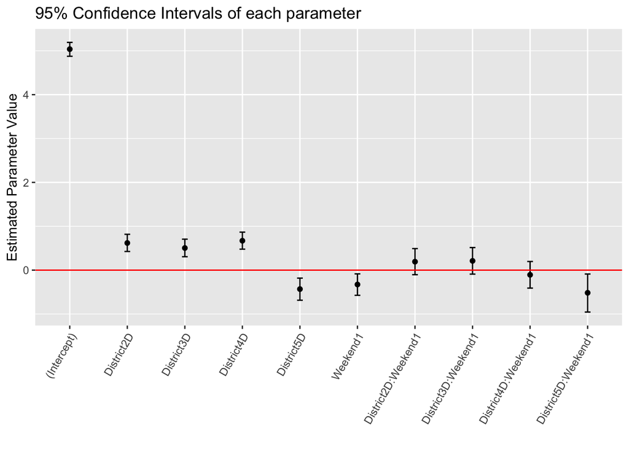

**post-COVID**

There are no interaction terms. Only 5th district parameter is insignificant at a significance level $\alpha = 0.05$. The base lien levels are “1D” and “Weekend0”. Therefore, for example, the relationship between the population parameter in 2D on weekend0 ($\mu_{2D,0}$) and the population parameter in 1D on weekend0 ($\mu_{1D,0}$) is like this: $\log(\mu_{2D,0}/\mu_{1D,0}) = 0.8643 \ (\rm{the \ estimated \ 2D \ parameter})$.

Model: Count ~ District + Weekend

|  | Estimate | Std. Error | z value | Pr(>\|z\|) |
| --- | --- | --- | --- | --- |
| (Intercept) | 3.8197 | 0.1198 | 31.8871 | 0.0000 |
| District2D | 0.8643 | 0.1377 | 6.2783 | 0.0000 |
| District3D | 0.6729 | 0.1419 | 4.7423 | 0.0000 |
| District4D | 0.8810 | 0.1373 | 6.4155 | 0.0000 |
| District5D | -0.3285 | 0.1785 | -1.8407 | 0.0657 |
| Weekend1 | -0.4384 | 0.0813 | -5.3934 | 0.0000 |

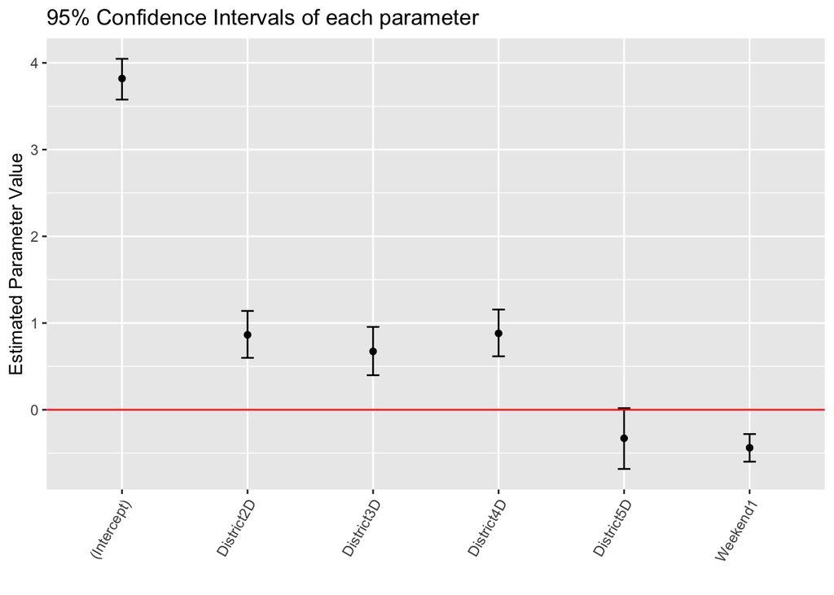

## Traffic Violations

```
##         Weekend
## District   0   1
##       1D 103  39
##       2D 244 101
##       3D 144  66
##       4D 229 118
##       5D 130  52
```

```
##         Weekend
## District  0  1
##       1D 10  7
##       2D 73 27
##       3D 18  9
##       4D 35  4
##       5D  9  3
```

### Summary of the models

#### pre-COVID models

```
##
## Call:
## glm(formula = Count ~ 1, family = poisson, data = DF_preCOVID_TV)
##
## Deviance Residuals:
##    Min      1Q  Median      3Q     Max
## -8.824  -4.710  -1.119   1.576   9.647
##
## Coefficients:
##             Estimate Std. Error z value Pr(>|z|)
## (Intercept)  4.80893    0.02856   168.4   <2e-16 ***
## ---
## Signif. codes:  0 '***' 0.001 '**' 0.01 '*' 0.05 '.' 0.1 ' ' 1
##
## (Dispersion parameter for poisson family taken to be 1)
##
##     Null deviance: 339.25  on 9  degrees of freedom
## Residual deviance: 339.25  on 9  degrees of freedom
## AIC: 406.24
##
## Number of Fisher Scoring iterations: 4
```

```
##
## Call:
## glm(formula = Count ~ District, family = poisson, data = DF_preCOVID_TV)
##
## Deviance Residuals:
##     25      50      75     102     125     147     172     196     219     243
##  3.556   5.121   3.601   4.014   3.839  -4.156  -5.905  -4.088  -4.475  -4.450
##
## Coefficients:
##             Estimate Std. Error z value Pr(>|z|)
## (Intercept)  4.26268    0.08392  50.796  < 2e-16 ***
## District2D   0.88772    0.09970   8.904  < 2e-16 ***
## District3D   0.39128    0.10865   3.601 0.000316 ***
## District4D   0.89350    0.09962   8.969  < 2e-16 ***
## District5D   0.24818    0.11197   2.217 0.026654 *
## ---
## Signif. codes:  0 '***' 0.001 '**' 0.01 '*' 0.05 '.' 0.1 ' ' 1
##
## (Dispersion parameter for poisson family taken to be 1)
##
##     Null deviance: 339.25  on 9  degrees of freedom
## Residual deviance: 191.36  on 5  degrees of freedom
## AIC: 266.35
##
## Number of Fisher Scoring iterations: 4
```

```
##
## Call:
## glm(formula = Count ~ Weekend, family = poisson, data = DF_preCOVID_TV)
##
## Deviance Residuals:
##    Min      1Q  Median      3Q     Max
## -5.548  -3.110  -1.566   3.928   5.324
##
## Coefficients:
##             Estimate Std. Error z value Pr(>|z|)
## (Intercept)  5.13580    0.03430  149.73   <2e-16 ***
## Weekend1    -0.81565    0.06194  -13.17   <2e-16 ***
## ---
## Signif. codes:  0 '***' 0.001 '**' 0.01 '*' 0.05 '.' 0.1 ' ' 1
##
## (Dispersion parameter for poisson family taken to be 1)
##
##     Null deviance: 339.25  on 9  degrees of freedom
## Residual deviance: 151.13  on 8  degrees of freedom
## AIC: 220.12
##
## Number of Fisher Scoring iterations: 4
```

```
##
## Call:
## glm(formula = Count ~ District + Weekend, family = poisson, data = DF_preCOVID_TV)
##
## Deviance Residuals:
##      25       50       75      102      125      147      172      196
##  0.4551   0.3098  -0.1325  -0.7526   0.3381  -0.7020  -0.4710   0.1980
##     219      243
##  1.1030  -0.5169
##
## Coefficients:
##             Estimate Std. Error z value Pr(>|z|)
## (Intercept)  4.58955    0.08604  53.342  < 2e-16 ***
## District2D   0.88772    0.09970   8.904  < 2e-16 ***
## District3D   0.39128    0.10865   3.601 0.000317 ***
## District4D   0.89350    0.09962   8.969  < 2e-16 ***
## District5D   0.24818    0.11197   2.217 0.026655 *
## Weekend1    -0.81565    0.06194 -13.169  < 2e-16 ***
## ---
## Signif. codes:  0 '***' 0.001 '**' 0.01 '*' 0.05 '.' 0.1 ' ' 1
##
## (Dispersion parameter for poisson family taken to be 1)
##
##     Null deviance: 339.251  on 9  degrees of freedom
## Residual deviance:   3.239  on 4  degrees of freedom
## AIC: 80.23
##
## Number of Fisher Scoring iterations: 3
```

```
##
## Call:
## glm(formula = Count ~ District * Weekend, family = poisson, data = DF_preCOVID_TV)
##
## Deviance Residuals:
##  [1]  0  0  0  0  0  0  0  0  0  0
##
## Coefficients:
##                     Estimate Std. Error z value Pr(>|z|)
## (Intercept)          4.63473    0.09853  47.037  < 2e-16 ***
## District2D           0.86244    0.11750   7.340 2.14e-13 ***
## District3D           0.33508    0.12905   2.597  0.00942 **
## District4D           0.79899    0.11864   6.735 1.64e-11 ***
## District5D           0.23281    0.13191   1.765  0.07759 .
## Weekend1            -0.97117    0.18802  -5.165 2.40e-07 ***
## District2D:Weekend1  0.08912    0.22215   0.401  0.68829
## District3D:Weekend1  0.19101    0.23968   0.797  0.42549
## District4D:Weekend1  0.30813    0.21952   1.404  0.16043
## District5D:Weekend1  0.05488    0.24955   0.220  0.82594
## ---
## Signif. codes:  0 '***' 0.001 '**' 0.01 '*' 0.05 '.' 0.1 ' ' 1
##
## (Dispersion parameter for poisson family taken to be 1)
##
##     Null deviance:  3.3925e+02  on 9  degrees of freedom
## Residual deviance: -4.0412e-14  on 0  degrees of freedom
## AIC: 84.991
##
## Number of Fisher Scoring iterations: 2
```

#### post-COVID models

```
##
## Call:
## glm(formula = Count ~ 1, family = poisson, data = DF_postCOVID_TV)
##
## Deviance Residuals:
##    Min      1Q  Median      3Q     Max
## -4.666  -3.114  -2.518   1.117   9.259
##
## Coefficients:
##             Estimate Std. Error z value Pr(>|z|)
## (Intercept)  2.97041    0.07161   41.48   <2e-16 ***
## ---
## Signif. codes:  0 '***' 0.001 '**' 0.01 '*' 0.05 '.' 0.1 ' ' 1
##
## (Dispersion parameter for poisson family taken to be 1)
##
##     Null deviance: 168.92  on 9  degrees of freedom
## Residual deviance: 168.92  on 9  degrees of freedom
## AIC: 214.66
##
## Number of Fisher Scoring iterations: 5
```

```
##
## Call:
## glm(formula = Count ~ District, family = poisson, data = DF_postCOVID_TV)
##
## Deviance Residuals:
##      20       46       70       92      114      131      151      168
##  0.5004   3.0417   1.1647   3.1536   1.1395  -0.5309  -3.5673  -1.3045
##     186      200
## -4.2810  -1.3569
##
## Coefficients:
##             Estimate Std. Error z value Pr(>|z|)
## (Intercept)   2.1401     0.2425   8.824  < 2e-16 ***
## District2D    1.7720     0.2623   6.754 1.43e-11 ***
## District3D    0.4626     0.3096   1.494  0.13512
## District4D    0.8303     0.2906   2.857  0.00428 **
## District5D   -0.3483     0.3770  -0.924  0.35559
## ---
## Signif. codes:  0 '***' 0.001 '**' 0.01 '*' 0.05 '.' 0.1 ' ' 1
##
## (Dispersion parameter for poisson family taken to be 1)
##
##     Null deviance: 168.92  on 9  degrees of freedom
## Residual deviance:  56.98  on 5  degrees of freedom
## AIC: 110.72
##
## Number of Fisher Scoring iterations: 5
```

```
##
## Call:
## glm(formula = Count ~ Weekend, family = poisson, data = DF_postCOVID_TV)
##
## Deviance Residuals:
##     Min       1Q   Median       3Q      Max
## -4.3519  -2.5018  -1.5821   0.7286   6.8397
##
## Coefficients:
##             Estimate Std. Error z value Pr(>|z|)
## (Intercept)  3.36730    0.08305  40.548  < 2e-16 ***
## Weekend1    -1.06471    0.16400  -6.492 8.47e-11 ***
## ---
## Signif. codes:  0 '***' 0.001 '**' 0.01 '*' 0.05 '.' 0.1 ' ' 1
##
## (Dispersion parameter for poisson family taken to be 1)
##
##     Null deviance: 168.92  on 9  degrees of freedom
## Residual deviance: 120.61  on 8  degrees of freedom
## AIC: 168.35
##
## Number of Fisher Scoring iterations: 5
```

```
##
## Call:
## glm(formula = Count ~ District + Weekend, family = poisson, data = DF_postCOVID_TV)
##
## Deviance Residuals:
##       20        46        70        92       114       131       151       168
## -0.77123  -0.15808  -0.47188   1.07873   0.02571   1.16163   0.26606   0.75413
##      186       200
## -2.16094  -0.04404
##
## Coefficients:
##             Estimate Std. Error z value Pr(>|z|)
## (Intercept)   2.5369     0.2462  10.306  < 2e-16 ***
## District2D    1.7720     0.2623   6.754 1.43e-11 ***
## District3D    0.4626     0.3096   1.494  0.13512
## District4D    0.8303     0.2906   2.857  0.00428 **
## District5D   -0.3483     0.3770  -0.924  0.35559
## Weekend1     -1.0647     0.1640  -6.492 8.47e-11 ***
## ---
## Signif. codes:  0 '***' 0.001 '**' 0.01 '*' 0.05 '.' 0.1 ' ' 1
##
## (Dispersion parameter for poisson family taken to be 1)
##
##     Null deviance: 168.9249  on 9  degrees of freedom
## Residual deviance:   8.6673  on 4  degrees of freedom
## AIC: 64.403
##
## Number of Fisher Scoring iterations: 4
```

```
##
## Call:
## glm(formula = Count ~ District * Weekend, family = poisson, data = DF_postCOVID_TV)
##
## Deviance Residuals:
##  [1]  0  0  0  0  0  0  0  0  0  0
##
## Coefficients:
##                     Estimate Std. Error z value Pr(>|z|)
## (Intercept)           2.3026     0.3162   7.281 3.30e-13 ***
## District2D            1.9879     0.3372   5.895 3.74e-09 ***
## District3D            0.5878     0.3944   1.490 0.136142
## District4D            1.2528     0.3586   3.494 0.000476 ***
## District5D           -0.1054     0.4595  -0.229 0.818628
## Weekend1             -0.3567     0.4928  -0.724 0.469210
## District2D:Weekend1  -0.6379     0.5418  -1.177 0.239049
## District3D:Weekend1  -0.3365     0.6399  -0.526 0.599036
## District4D:Weekend1  -1.8124     0.7221  -2.510 0.012077 *
## District5D:Weekend1  -0.7419     0.8290  -0.895 0.370820
## ---
## Signif. codes:  0 '***' 0.001 '**' 0.01 '*' 0.05 '.' 0.1 ' ' 1
##
## (Dispersion parameter for poisson family taken to be 1)
##
##     Null deviance:  1.6892e+02  on 9  degrees of freedom
## Residual deviance: -3.7748e-15  on 0  degrees of freedom
## AIC: 63.736
##
## Number of Fisher Scoring iterations: 3
```

### Deviance

I tested the below hypothesis at a significance level $\alpha=0.05$:
$$H_0: \ \rm{Reduced \ model \ is \ true.}$$
$$H_1: \ \rm{Satureated \ model \ (Model \ 5)
\ is \ true.}$$

**pre-COVID**

$H_0$ is not rejected for Model 4.

```
## [1] 1.200187e-67
```

```
## [1] 1.999304e-39
```

```
## [1] 1.140255e-28
```

```
## [1] 0.518658
```

**post-COVID**

$H_0$ is not rejected for Model 4.

```
## [1] 1.033356e-31
```

```
## [1] 5.105366e-11
```

```
## [1] 2.477926e-22
```

```
## [1] 0.06997617
```

### AIC and BIC

Each model’s AIC and BIC was as follows.

**pre-COVID**

Model 4 is the best in terms of AIC and BIC.

```
## [1] "AIC"
```

```
## [1] 406.2411
```

```
## [1] 266.3515
```

```
## [1] 220.1191
```

```
## [1] 80.22952
```

```
## [1] 84.99054
```

```
## [1] "BIC"
```

```
## [1] 406.5437
```

```
## [1] 267.8645
```

```
## [1] 220.7243
```

```
## [1] 82.04503
```

```
## [1] 88.01639
```

**post-COVID**

Model 5 is the best in terms of AIC, but Model 4 is the best from BIC. According to Chakrabarti & Ghosh (2011), “The Bayesian Information Criterion (BIC) is more useful in selecting a correct model while the AIC is more appropriate in finding the best model for predicting future observations.” I want to select the correct model, not a model with high predictive power, so I will focus on the BIC results.

```
## [1] "AIC"
```

```
## [1] 214.6605
```

```
## [1] 110.7155
```

```
## [1] 168.3478
```

```
## [1] 64.40279
```

```
## [1] 63.73553
```

```
## [1] "BIC"
```

```
## [1] 214.963
```

```
## [1] 112.2284
```

```
## [1] 168.953
```

```
## [1] 66.2183
```

```
## [1] 66.76138
```

### Best Model

Independence model is the best for pre-COVID and post-COVID.

#### Parameters

**pre-COVID**  
All parameters are significant at a significance level $\alpha = 0.05$. The base lien levels are “1D” and “Weekend0”. Therefore, for example, the relationship between the population parameter in 2D on weekend0 ($\mu_{2D,0}$) and the population parameter in 4D on weekend0 ($\mu_{4D,0}$) is like this: $\log(\mu_{2D,0}/\mu_{4D,0}) = 0.8877 \ ({\rm{the \ estimated \ 2D \ parameter}}) - 0.8935 \ ({\rm{the \ estimated \ 4D \ parameter}}) = -0.0058$.

Model: Count ~ District + Weekend

|  | Estimate | Std. Error | z value | Pr(>\|z\|) |
| --- | --- | --- | --- | --- |
| (Intercept) | 4.5896 | 0.0860 | 53.3415 | 0.0000 |
| District2D | 0.8877 | 0.0997 | 8.9036 | 0.0000 |
| District3D | 0.3913 | 0.1086 | 3.6014 | 0.0003 |
| District4D | 0.8935 | 0.0996 | 8.9691 | 0.0000 |
| District5D | 0.2482 | 0.1120 | 2.2165 | 0.0267 |
| Weekend1 | -0.8156 | 0.0619 | -13.1693 | 0.0000 |

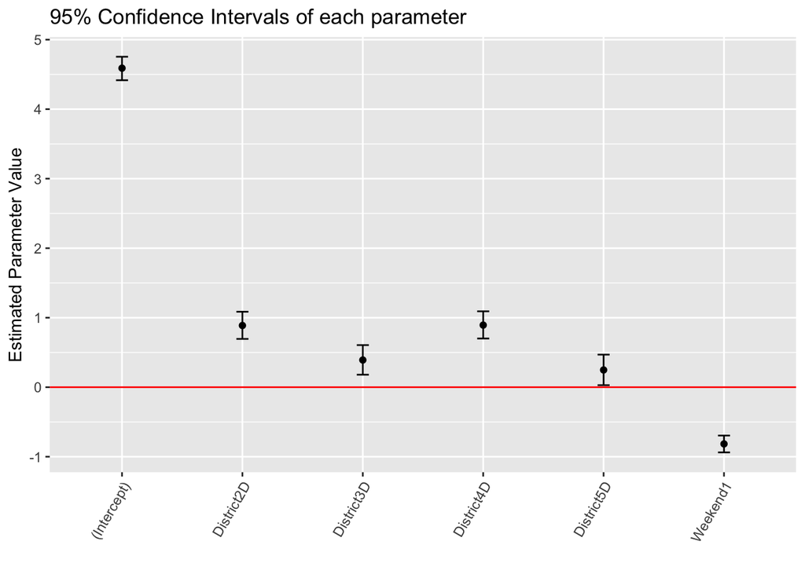

**post-COVID**  
“3D” and “5D” parameters are insignificant at a significance level $\alpha = 0.05$. The base lien levels are “1D” and “Weekend0”. Therefore, for example, the relationship between the population parameter in 2D on weekend0 ($\mu_{2D,0}$) and the population parameter in 4D on weekend0 ($\mu_{4D,0}$) is like this: $\log(\mu_{2D,0}/\mu_{4D,0}) = 1.7720 \ ({\rm{the \ estimated \ 2D \ parameter}}) - 0.8303 \ ({\rm{the \ estimated \ 4D \ parameter}}) = 0.9417$.

Model: Count ~ District + Weekend

|  | Estimate | Std. Error | z value | Pr(>\|z\|) |
| --- | --- | --- | --- | --- |
| (Intercept) | 2.5369 | 0.2462 | 10.3063 | 0.0000 |
| District2D | 1.7720 | 0.2623 | 6.7544 | 0.0000 |
| District3D | 0.4626 | 0.3096 | 1.4942 | 0.1351 |
| District4D | 0.8303 | 0.2906 | 2.8571 | 0.0043 |
| District5D | -0.3483 | 0.3770 | -0.9238 | 0.3556 |
| Weekend1 | -1.0647 | 0.1640 | -6.4921 | 0.0000 |

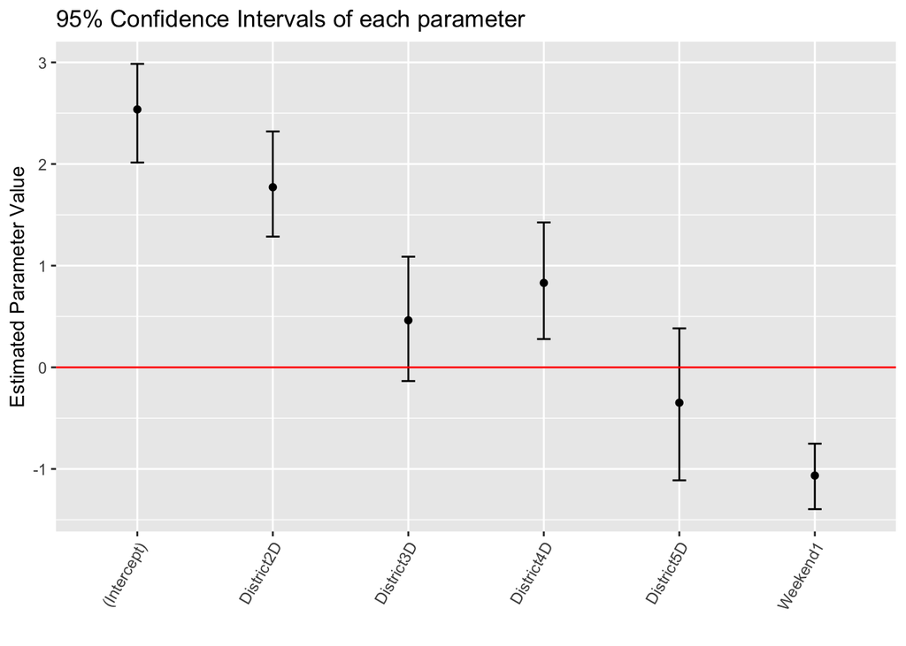

## Theft

```
##         Weekend
## District   0   1
##       1D  55  25
##       2D 126  43
##       3D 118  37
##       4D  70  22
##       5D  63  25
```

```
##         Weekend
## District  0  1
##       1D  7  1
##       2D 14  8
##       3D 15  2
##       4D  6  2
##       5D 18 11
```

### Summary of the models

#### pre-COVID models

```
##
## Call:
## glm(formula = Count ~ 1, family = poisson, data = DF_preCOVID_Th)
##
## Deviance Residuals:
##    Min      1Q  Median      3Q     Max
## -5.463  -4.454  -1.282   1.252   7.654
##
## Coefficients:
##             Estimate Std. Error z value Pr(>|z|)
## (Intercept)  4.06732    0.04138   98.29   <2e-16 ***
## ---
## Signif. codes:  0 '***' 0.001 '**' 0.01 '*' 0.05 '.' 0.1 ' ' 1
##
## (Dispersion parameter for poisson family taken to be 1)
##
##     Null deviance: 200.2  on 9  degrees of freedom
## Residual deviance: 200.2  on 9  degrees of freedom
## AIC: 259.52
##
## Number of Fisher Scoring iterations: 5
```

```
##
## Call:
## glm(formula = Count ~ District, family = poisson, data = DF_preCOVID_Th)
##
## Deviance Residuals:
##     23      48      73     100     124     145     170     195     217     241
##  2.243   4.205   4.268   3.283   2.688  -2.550  -4.990  -5.127  -3.943  -3.120
##
## Coefficients:
##             Estimate Std. Error z value Pr(>|z|)
## (Intercept)  3.68888    0.11180  32.994  < 2e-16 ***
## District2D   0.74787    0.13571   5.511 3.57e-08 ***
## District3D   0.66140    0.13766   4.804 1.55e-06 ***
## District4D   0.13976    0.15287   0.914    0.361
## District5D   0.09531    0.15448   0.617    0.537
## ---
## Signif. codes:  0 '***' 0.001 '**' 0.01 '*' 0.05 '.' 0.1 ' ' 1
##
## (Dispersion parameter for poisson family taken to be 1)
##
##     Null deviance: 200.2  on 9  degrees of freedom
## Residual deviance: 141.9  on 5  degrees of freedom
## AIC: 209.23
##
## Number of Fisher Scoring iterations: 4
```

```
##
## Call:
## glm(formula = Count ~ Weekend, family = poisson, data = DF_preCOVID_Th)
##
## Deviance Residuals:
##    Min      1Q  Median      3Q     Max
## -3.622  -1.770  -1.011   1.902   3.985
##
## Coefficients:
##             Estimate Std. Error z value Pr(>|z|)
## (Intercept)  4.45899    0.04811   92.68   <2e-16 ***
## Weekend1    -1.04455    0.09431  -11.08   <2e-16 ***
## ---
## Signif. codes:  0 '***' 0.001 '**' 0.01 '*' 0.05 '.' 0.1 ' ' 1
##
## (Dispersion parameter for poisson family taken to be 1)
##
##     Null deviance: 200.195  on 9  degrees of freedom
## Residual deviance:  60.264  on 8  degrees of freedom
## AIC: 121.59
##
## Number of Fisher Scoring iterations: 4
```

```
##
## Call:
## glm(formula = Count ~ District + Weekend, family = poisson, data = DF_preCOVID_Th)
##
## Deviance Residuals:
##      23       48       73      100      124      145      170      195
## -0.5497   0.0881   0.3106   0.2347  -0.2612   0.8873  -0.1493  -0.5338
##     217      241
## -0.4031   0.4315
##
## Coefficients:
##             Estimate Std. Error z value Pr(>|z|)
## (Intercept)  4.08055    0.11447  35.649  < 2e-16 ***
## District2D   0.74787    0.13571   5.511 3.57e-08 ***
## District3D   0.66140    0.13766   4.804 1.55e-06 ***
## District4D   0.13976    0.15287   0.914    0.361
## District5D   0.09531    0.15448   0.617    0.537
## Weekend1    -1.04455    0.09431 -11.076  < 2e-16 ***
## ---
## Signif. codes:  0 '***' 0.001 '**' 0.01 '*' 0.05 '.' 0.1 ' ' 1
##
## (Dispersion parameter for poisson family taken to be 1)
##
##     Null deviance: 200.1952  on 9  degrees of freedom
## Residual deviance:   1.9729  on 4  degrees of freedom
## AIC: 71.299
##
## Number of Fisher Scoring iterations: 4
```

```
##
## Call:
## glm(formula = Count ~ District * Weekend, family = poisson, data = DF_preCOVID_Th)
##
## Deviance Residuals:
##  [1]  0  0  0  0  0  0  0  0  0  0
##
## Coefficients:
##                     Estimate Std. Error z value Pr(>|z|)
## (Intercept)           4.0073     0.1348  29.719  < 2e-16 ***
## District2D            0.8289     0.1616   5.129 2.91e-07 ***
## District3D            0.7634     0.1633   4.675 2.93e-06 ***
## District4D            0.2412     0.1802   1.338  0.18077
## District5D            0.1358     0.1845   0.736  0.46180
## Weekend1             -0.7885     0.2412  -3.269  0.00108 **
## District2D:Weekend1  -0.2866     0.2990  -0.959  0.33768
## District3D:Weekend1  -0.3713     0.3061  -1.213  0.22508
## District4D:Weekend1  -0.3690     0.3434  -1.075  0.28258
## District5D:Weekend1  -0.1358     0.3377  -0.402  0.68760
## ---
## Signif. codes:  0 '***' 0.001 '**' 0.01 '*' 0.05 '.' 0.1 ' ' 1
##
## (Dispersion parameter for poisson family taken to be 1)
##
##     Null deviance: 2.0020e+02  on 9  degrees of freedom
## Residual deviance: 5.7732e-15  on 0  degrees of freedom
## AIC: 77.326
##
## Number of Fisher Scoring iterations: 3
```

#### post-COVID models

```
##
## Call:
## glm(formula = Count ~ 1, family = poisson, data = DF_postCOVID_Th)
##
## Deviance Residuals:
##     Min       1Q   Median       3Q      Max
## -3.2471  -2.2110  -0.3183   1.5352   2.8700
##
## Coefficients:
##             Estimate Std. Error z value Pr(>|z|)
## (Intercept)   2.1282     0.1091   19.51   <2e-16 ***
## ---
## Signif. codes:  0 '***' 0.001 '**' 0.01 '*' 0.05 '.' 0.1 ' ' 1
##
## (Dispersion parameter for poisson family taken to be 1)
##
##     Null deviance: 41.959  on 9  degrees of freedom
## Residual deviance: 41.959  on 9  degrees of freedom
## AIC: 80.624
##
## Number of Fisher Scoring iterations: 5
```

```
##
## Call:
## glm(formula = Count ~ District, family = poisson, data = DF_postCOVID_Th)
##
## Deviance Residuals:
##      18       44       68       91      113      130      150      167
##  1.3545   0.8675   2.0099   0.9304   0.8855  -1.7965  -0.9512  -2.6856
##     185      199
## -1.1079  -0.9604
##
## Coefficients:
##               Estimate Std. Error z value Pr(>|z|)
## (Intercept)  1.386e+00  3.536e-01   3.921 8.82e-05 ***
## District2D   1.012e+00  4.129e-01   2.450  0.01428 *
## District3D   7.538e-01  4.287e-01   1.758  0.07873 .
## District4D  -5.455e-14  5.000e-01   0.000  1.00000
## District5D   1.288e+00  3.994e-01   3.225  0.00126 **
## ---
## Signif. codes:  0 '***' 0.001 '**' 0.01 '*' 0.05 '.' 0.1 ' ' 1
##
## (Dispersion parameter for poisson family taken to be 1)
##
##     Null deviance: 41.959  on 9  degrees of freedom
## Residual deviance: 21.771  on 5  degrees of freedom
## AIC: 68.435
##
## Number of Fisher Scoring iterations: 5
```

```
##
## Call:
## glm(formula = Count ~ Weekend, family = poisson, data = DF_postCOVID_Th)
##
## Deviance Residuals:
##     Min       1Q   Median       3Q      Max
## -2.1125  -1.5370  -0.4431   1.2070   2.4175
##
## Coefficients:
##             Estimate Std. Error z value Pr(>|z|)
## (Intercept)   2.4849     0.1291  19.248  < 2e-16 ***
## Weekend1     -0.9163     0.2415  -3.794 0.000148 ***
## ---
## Signif. codes:  0 '***' 0.001 '**' 0.01 '*' 0.05 '.' 0.1 ' ' 1
##
## (Dispersion parameter for poisson family taken to be 1)
##
##     Null deviance: 41.959  on 9  degrees of freedom
## Residual deviance: 26.020  on 8  degrees of freedom
## AIC: 66.685
##
## Number of Fisher Scoring iterations: 5
```

```
##
## Call:
## glm(formula = Count ~ District + Weekend, family = poisson, data = DF_postCOVID_Th)
##
## Deviance Residuals:
##      18       44       68       91      113      130      150      167
##  0.5194  -0.4407   0.7906   0.1186  -0.6102  -0.9582   0.6558  -1.4714
##     185      199
## -0.1931   0.8974
##
## Coefficients:
##               Estimate Std. Error z value Pr(>|z|)
## (Intercept)  1.743e+00  3.602e-01   4.839 1.31e-06 ***
## District2D   1.012e+00  4.129e-01   2.450 0.014277 *
## District3D   7.538e-01  4.287e-01   1.758 0.078732 .
## District4D  -4.306e-11  5.000e-01   0.000 1.000000
## District5D   1.288e+00  3.994e-01   3.225 0.001260 **
## Weekend1    -9.163e-01  2.415e-01  -3.794 0.000148 ***
## ---
## Signif. codes:  0 '***' 0.001 '**' 0.01 '*' 0.05 '.' 0.1 ' ' 1
##
## (Dispersion parameter for poisson family taken to be 1)
##
##     Null deviance: 41.9594  on 9  degrees of freedom
## Residual deviance:  5.8312  on 4  degrees of freedom
## AIC: 54.496
##
## Number of Fisher Scoring iterations: 4
```

```
##
## Call:
## glm(formula = Count ~ District * Weekend, family = poisson, data = DF_postCOVID_Th)
##
## Deviance Residuals:
##  [1]  0  0  0  0  0  0  0  0  0  0
##
## Coefficients:
##                     Estimate Std. Error z value Pr(>|z|)
## (Intercept)          1.94591    0.37796   5.148 2.63e-07 ***
## District2D           0.69315    0.46291   1.497   0.1343
## District3D           0.76214    0.45774   1.665   0.0959 .
## District4D          -0.15415    0.55635  -0.277   0.7817
## District5D           0.94446    0.44544   2.120   0.0340 *
## Weekend1            -1.94591    1.06904  -1.820   0.0687 .
## District2D:Weekend1  1.38629    1.15727   1.198   0.2310
## District3D:Weekend1 -0.06899    1.30748  -0.053   0.9579
## District4D:Weekend1  0.84730    1.34518   0.630   0.5288
## District5D:Weekend1  1.45343    1.13548   1.280   0.2005
## ---
## Signif. codes:  0 '***' 0.001 '**' 0.01 '*' 0.05 '.' 0.1 ' ' 1
##
## (Dispersion parameter for poisson family taken to be 1)
##
##     Null deviance:  4.1959e+01  on 9  degrees of freedom
## Residual deviance: -2.2205e-16  on 0  degrees of freedom
## AIC: 56.665
##
## Number of Fisher Scoring iterations: 3
```

### Deviance

I tested the below hypothesis at a significance level $\alpha=0.05$:
$$H_0: \ \rm{Reduced \ model \ is \ true.}$$
$$H_1: \ \rm{Satureated \ model \ (Model \ 5)
\ is \ true.}$$

**pre-COVID**

$H_0$ is not rejected for Model 4.

```
## [1] 3.015098e-38
```

```
## [1] 7.045701e-29
```

```
## [1] 4.136469e-10
```

```
## [1] 0.7407383
```

**post-COVID**

$H_0$ is not rejected for Model 4.

```
## [1] 3.343243e-06
```

```
## [1] 0.0005788622
```

```
## [1] 0.001042085
```

```
## [1] 0.2121164
```

### AIC and BIC

Each model’s AIC and BIC was as follows.

**pre-COVID**

Model 4 is the best in terms of AIC and BIC.

```
## [1] "AIC"
```

```
## [1] 259.5209
```

```
## [1] 209.2296
```

```
## [1] 121.5899
```

```
## [1] 71.29862
```

```
## [1] 77.32569
```

```
## [1] "BIC"
```

```
## [1] 259.8235
```

```
## [1] 210.7425
```

```
## [1] 122.1951
```

```
## [1] 73.11413
```

```
## [1] 80.35154
```

**post-COVID**

Model 4 is the best in terms of AIC and BIC.

```
## [1] "AIC"
```

```
## [1] 80.62418
```

```
## [1] 68.43543
```

```
## [1] 66.68475
```

```
## [1] 54.49599
```

```
## [1] 56.66482
```

```
## [1] "BIC"
```

```
## [1] 80.92677
```

```
## [1] 69.94835
```

```
## [1] 67.28992
```

```
## [1] 56.3115
```

```
## [1] 59.69067
```

### Best Model

**pre-COVID**  
“4D” and “5D” parameters are insignificant at a significance level $\alpha = 0.05$. The base lien levels are “1D” and “Weekend0”. Therefore, for example, the relationship between the population parameter in 5D on weekend0 ($\mu_{5D,0}$) and the population parameter in 2D on weekend0 ($\mu_{2D,0}$) is like this: $\log(\mu_{5D,0}/\mu_{2D,0}) = 0.0953 \ ({\rm{the \ estimated \ 5D \ parameter}}) - 0.7479 \ ({\rm{the \ estimated \ 2D \ parameter}}) = -0.6526$.

Model: Count ~ District + Weekend

|  | Estimate | Std. Error | z value | Pr(>\|z\|) |
| --- | --- | --- | --- | --- |
| (Intercept) | 4.0806 | 0.1145 | 35.6486 | 0.0000 |
| District2D | 0.7479 | 0.1357 | 5.5108 | 0.0000 |
| District3D | 0.6614 | 0.1377 | 4.8044 | 0.0000 |
| District4D | 0.1398 | 0.1529 | 0.9142 | 0.3606 |
| District5D | 0.0953 | 0.1545 | 0.6170 | 0.5372 |
| Weekend1 | -1.0445 | 0.0943 | -11.0760 | 0.0000 |

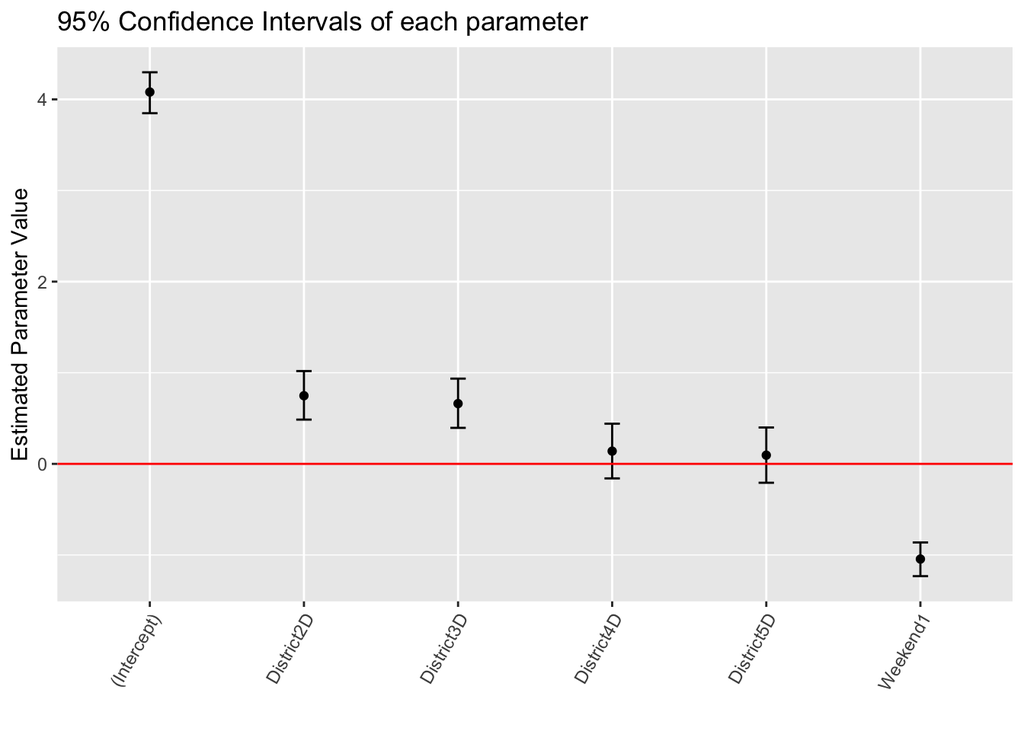

**post-COVID**  
“3D” and “4D” parameters are insignificant at a significance level $\alpha = 0.05$. The base lien levels are “1D” and “Weekend0”. Therefore, for example, the relationship between the population parameter in 5D on weekend0 ($\mu_{5D,0}$) and the population parameter in 2D on weekend0 ($\mu_{2D,0}$) is like this: $\log(\mu_{5D,0}/\mu_{2D,0}) = 1.2879 \ ({\rm{the \ estimated \ 5D \ parameter}}) - 1.0116 \ ({\rm{the \ estimated \ 2D \ parameter}}) = 0.2763$.

Model: Count ~ District + Weekend

|  | Estimate | Std. Error | z value | Pr(>\|z\|) |
| --- | --- | --- | --- | --- |
| (Intercept) | 1.7430 | 0.3602 | 4.8386 | 0.0000 |
| District2D | 1.0116 | 0.4129 | 2.4502 | 0.0143 |
| District3D | 0.7538 | 0.4287 | 1.7581 | 0.0787 |
| District4D | 0.0000 | 0.5000 | 0.0000 | 1.0000 |
| District5D | 1.2879 | 0.3994 | 3.2249 | 0.0013 |
| Weekend1 | -0.9163 | 0.2415 | -3.7938 | 0.0001 |

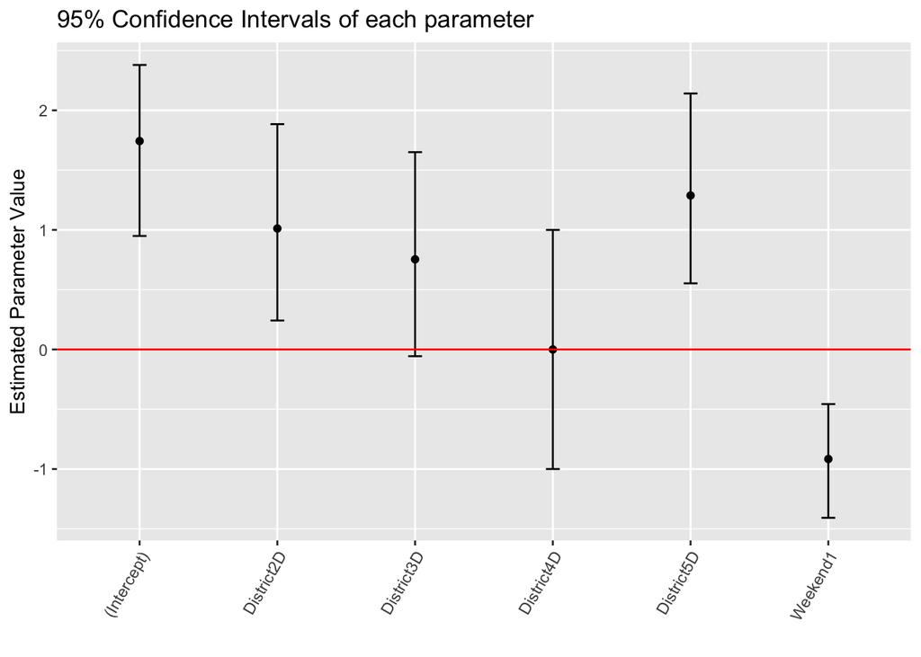

# Analysis using 3 categorical variables

### Build a dataframe with 3 categories (District, weekdays, generation)

District: 1D-5D

Weekday: Monday-Sunday

generation: A(18-24),B(25-39), C(40-59), D(60-80), the sample above 80 is not adequate for analysis

```
##        Arrestee_Type Arrest_Year Arrest_Date Month Day Arrest_Hour Age
## 118136  Adult Arrest        2019  2019-12-30    12  30           7  25
## 118162  Adult Arrest        2019  2019-12-31    12  31          11  24
## 118205  Adult Arrest        2019  2019-12-31    12  31           6  32
## 118206  Adult Arrest        2019  2019-12-31    12  31           6  49
## 118213  Adult Arrest        2019  2019-12-31    12  31           7  42
## 118237  Adult Arrest        2019  2019-12-31    12  31           9  42
##        Defendant_PSA Defendant_District Defendant_Race Defendant_Ethnicity
## 118136           405                 4D          WHITE            HISPANIC
## 118162           304                 3D          WHITE        NOT HISPANIC
## 118205           407                 4D          WHITE            HISPANIC
## 118206           305                 3D          WHITE             UNKNOWN
## 118213           506                 5D          WHITE            HISPANIC
## 118237           301                 3D          WHITE             UNKNOWN
##        Defendant_Sex                   Arrest_Category
```

[output cut: 20 more lines]

```
##        Arrestee_Type Arrest_Year Arrest_Date Month Day Arrest_Hour Age
## 118260  Adult Arrest        2020  2020-01-01    01   1           1  37
## 118262  Adult Arrest        2020  2020-01-01    01   1           2  21
## 118268  Adult Arrest        2020  2020-01-01    01   1           2  42
## 118276  Adult Arrest        2020  2020-01-01    01   1           3  29
## 118281  Adult Arrest        2020  2020-01-01    01   1           3  42
## 118302  Adult Arrest        2020  2020-01-01    01   1           8  24
##        Defendant_PSA Defendant_District Defendant_Race Defendant_Ethnicity
## 118260          <NA>                             WHITE        NOT HISPANIC
## 118262          <NA>                             WHITE        NOT HISPANIC
## 118268           404                 4D          WHITE            HISPANIC
## 118276          <NA>                             WHITE             UNKNOWN
## 118281          <NA>                             WHITE             UNKNOWN
## 118302          <NA>                             WHITE            HISPANIC
##        Defendant_Sex Arrest_Category                      Charge_Description
## 118260          MALE    Other Crimes                          Unlawful Entry
## 118262          MALE  Simple Assault                          Simple Assault
## 118268          MALE  Simple Assault                          Simple Assault
## 118276          MALE  Simple Assault                          Simple Assault
## 118281          MALE  Simple Assault                          Simple Assault
## 118302          MALE           Theft Theft Second Degree (all Other Larceny)
##        Arrest_Location_District Offense_Location_District   Weekday
## 118260                       3D                        3D Wednesday
## 118262                       2D                        2D Wednesday
## 118268                       4D                        4D Wednesday
## 118276                       2D                        2D Wednesday
## 118281                       2D                        2D Wednesday
## 118302                       4D                        4D Wednesday
```

Count Pre-Covid Crimes

Build Data Frame for Pre-Covid Crimes

```
##   Dist weekday generation Simple_Assult_counts Traffic_Violations_counts
## 1   1D  Monday          A                    7                         7
## 2   1D  Monday          B                   19                        10
## 3   1D  Monday          C                   12                         3
## 4   1D  Monday          D                   NA                         2
## 5   1D Tuesday          A                   NA                         4
## 6   1D Tuesday          B                   12                        12
##   Theft_counts
## 1            2
## 2           10
## 3            6
## 4            2
## 5            2
## 6            5
```

```
## [1] 140
```

Count Post-Covid Crimes

Build Data Frame for Post-Covid Crimes

```
##   Dist weekday generation Simple_Assult_counts Traffic_Violations_counts
## 1   1D  Monday          A                    2                        NA
## 2   1D  Monday          B                    4                         1
## 3   1D  Monday          C                    6                        NA
## 4   1D  Monday          D                   NA                        NA
## 5   1D Tuesday          A                    1                        NA
## 6   1D Tuesday          B                    3                         2
##   Theft_counts
## 1           NA
## 2           NA
## 3            1
## 4           NA
## 5           NA
## 6            2
```

```
## [1] 140
```

### Doing Loglm

Modeling for three crime categories: **Simple Assult**, **Traffic Violations**, and **Theft**.

I will use **C** as the **generation** feature

#### Independence model ~A + B + C

Pre-Covid

```r
library(MASS)
loglm_independent_SA<- loglm(Simple_Assult_counts~Dist+weekday+generation, data=crime_dist_weekday_age )
loglm_independent_TV<- loglm(Traffic_Violations_counts~Dist+weekday+generation, data=crime_dist_weekday_age )
loglm_independent_Theft<- loglm(Theft_counts~Dist+weekday+generation, data=crime_dist_weekday_age )

glm_independent_SA<-glm(Simple_Assult_counts~Dist+weekday+generation, data=crime_dist_weekday_age,family=poisson )

glm_independent_TV<-glm(Traffic_Violations_counts~Dist+weekday+generation, data=crime_dist_weekday_age,family=poisson )

glm_independent_Theft<-glm(Theft_counts~Dist+weekday+generation, data=crime_dist_weekday_age,family=poisson )

#AIC(glm_independent_SA)
#AIC(glm_independent_TV)
#AIC(glm_independent_Theft)

#BIC(glm_independent_SA)
#BIC(glm_independent_TV)
#BIC(glm_independent_Theft)
```

Post-Covid

```r
loglm_independent_SA_post<- loglm(Simple_Assult_counts~Dist+weekday+generation, data=crime_dist_weekday_age_post )
loglm_independent_TV_post<- loglm(Traffic_Violations_counts~Dist+weekday+generation, data=crime_dist_weekday_age_post )
loglm_independent_Theft_post<- loglm(Theft_counts~Dist+weekday+generation, data=crime_dist_weekday_age_post )

glm_independent_SA_post<-glm(Simple_Assult_counts~Dist+weekday+generation, data=crime_dist_weekday_age_post,family=poisson )

glm_independent_TV_post<-glm(Traffic_Violations_counts~Dist+weekday+generation, data=crime_dist_weekday_age_post,family=poisson )

glm_independent_Theft_post<-glm(Theft_counts~Dist+weekday+generation, data=crime_dist_weekday_age_post,family=poisson )

#AIC(glm_independent_SA_post)
#AIC(glm_independent_TV_post)
#AIC(glm_independent_Theft_post)

#BIC(glm_independent_SA_post)
#BIC(glm_independent_TV_post)
#BIC(glm_independent_Theft_post)
```

#### Conditional independence ~(A+B)*C

Pre-Covid

```r
loglm_condition_SA <- loglm(Simple_Assult_counts~(Dist + weekday) * generation, data=crime_dist_weekday_age)
loglm_condition_TV <- loglm(Traffic_Violations_counts~(Dist + weekday) * generation, data=crime_dist_weekday_age)
loglm_condition_Theft <- loglm(Theft_counts~(Dist + weekday) * generation, data=crime_dist_weekday_age)

glm_condition_SA<-glm(Simple_Assult_counts~(Dist + weekday) * generation, data=crime_dist_weekday_age,family = poisson)

glm_condition_TV<-glm(Traffic_Violations_counts~(Dist + weekday) * generation, data=crime_dist_weekday_age,family = poisson)

glm_condition_Theft<-glm(Theft_counts~(Dist + weekday) * generation, data=crime_dist_weekday_age,family = poisson)

#AIC(glm_condition_SA)
#AIC(glm_condition_TV)
#AIC(glm_condition_Theft)

#BIC(glm_condition_SA)
#BIC(glm_condition_TV)
#BIC(glm_condition_Theft)
```

Post-Covid

```r
loglm_condition_SA_post <- loglm(Simple_Assult_counts~(Dist + weekday) * generation, data=crime_dist_weekday_age_post)
loglm_condition_TV_post <- loglm(Traffic_Violations_counts~(Dist + weekday) * generation, data=crime_dist_weekday_age_post)
loglm_condition_Theft_post <- loglm(Theft_counts~(Dist + weekday) * generation, data=crime_dist_weekday_age_post)

glm_condition_SA_post<-glm(Simple_Assult_counts~(Dist + weekday) * generation, data=crime_dist_weekday_age_post,family = poisson)

glm_condition_TV_post<-glm(Traffic_Violations_counts~(Dist + weekday) * generation, data=crime_dist_weekday_age_post,family = poisson)

glm_condition_Theft_post<-glm(Theft_counts~(Dist + weekday) * generation, data=crime_dist_weekday_age_post,family = poisson)

#AIC(glm_condition_SA_post)
#AIC(glm_condition_TV_post)
#AIC(glm_condition_Theft_post)

#BIC(glm_condition_SA_post)
#BIC(glm_condition_TV_post)
#BIC(glm_condition_Theft_post)
```

#### Joint independence ~A*B + C

Pre-Covid

```r
loglm_joint_SA <- loglm(Simple_Assult_counts~(Dist * weekday)+ generation, data=crime_dist_weekday_age)
loglm_joint_TV <- loglm(Traffic_Violations_counts~(Dist * weekday)+ generation, data=crime_dist_weekday_age)
loglm_joint_Theft <- loglm(Theft_counts~(Dist * weekday)+ generation, data=crime_dist_weekday_age)


glm_joint_SA <- glm(Simple_Assult_counts~(Dist * weekday)+ generation, data=crime_dist_weekday_age,family = poisson)

glm_joint_TV <- glm(Traffic_Violations_counts~(Dist * weekday)+ generation, data=crime_dist_weekday_age,family = poisson)

glm_joint_Theft <- glm(Theft_counts~(Dist * weekday)+ generation, data=crime_dist_weekday_age,family = poisson)

#AIC(glm_joint_SA)
#AIC(glm_joint_TV)
#AIC(glm_joint_Theft)

#BIC(glm_joint_SA)
#BIC(glm_joint_TV)
#BIC(glm_joint_Theft)
```

Post-Covid

```r
loglm_joint_SA_post <- loglm(Simple_Assult_counts~(Dist * weekday)+ generation, data=crime_dist_weekday_age_post)
loglm_joint_TV_post <- loglm(Traffic_Violations_counts~(Dist * weekday)+ generation, data=crime_dist_weekday_age_post)
loglm_joint_Theft_post <- loglm(Theft_counts~(Dist * weekday)+ generation, data=crime_dist_weekday_age_post)


glm_joint_SA_post <- glm(Simple_Assult_counts~(Dist * weekday)+ generation, data=crime_dist_weekday_age_post,family = poisson)

glm_joint_TV_post <- glm(Traffic_Violations_counts~(Dist * weekday)+ generation, data=crime_dist_weekday_age_post,family = poisson)

glm_joint_Theft_post <- glm(Theft_counts~(Dist * weekday)+ generation, data=crime_dist_weekday_age_post,family = poisson)

#AIC(glm_joint_SA_post)
#AIC(glm_joint_TV_post)
#AIC(glm_joint_Theft_post)

#BIC(glm_joint_SA_post)
#BIC(glm_joint_TV_post)
#BIC(glm_joint_Theft_post)
```

#### All two-way associations ~A*B + A*C + B*C

Pre-Covid

```r
loglm_ATWA_SA <- loglm(Simple_Assult_counts~(Dist * weekday)+ generation*weekday+Dist*generation, data=crime_dist_weekday_age)
loglm_ATWA_TV <- loglm(Traffic_Violations_counts~(Dist * weekday)+ generation*weekday+Dist*generation, data=crime_dist_weekday_age)
loglm_ATWA_Theft <- loglm(Theft_counts~(Dist * weekday)+ generation*weekday+Dist*generation, data=crime_dist_weekday_age)

glm_ATWA_SA <- glm(Simple_Assult_counts~(Dist * weekday)+ generation*weekday+Dist*generation, data=crime_dist_weekday_age,family = poisson)
glm_ATWA_TV<- glm(Traffic_Violations_counts~(Dist * weekday)+ generation*weekday+Dist*generation, data=crime_dist_weekday_age,family = poisson)
glm_ATWA_Theft <- glm(Theft_counts~(Dist * weekday)+ generation*weekday+Dist*generation, data=crime_dist_weekday_age,family = poisson)

#AIC(glm_ATWA_SA)
#AIC(glm_ATWA_TV)
#AIC(glm_ATWA_Theft)

#BIC(glm_ATWA_SA)
#BIC(glm_ATWA_TV)
#BIC(glm_ATWA_Theft)
```

Post-Covid

```r
loglm_ATWA_SA_post <- loglm(Simple_Assult_counts~(Dist * weekday)+ generation*weekday+Dist*generation, data=crime_dist_weekday_age_post)
loglm_ATWA_TV_post <- loglm(Traffic_Violations_counts~(Dist * weekday)+ generation*weekday+Dist*generation, data=crime_dist_weekday_age_post)
loglm_ATWA_Theft_post <- loglm(Theft_counts~(Dist * weekday)+ generation*weekday+Dist*generation, data=crime_dist_weekday_age_post)

glm_ATWA_SA_post <- glm(Simple_Assult_counts~(Dist * weekday)+ generation*weekday+Dist*generation, data=crime_dist_weekday_age_post,family = poisson)
glm_ATWA_TV_post<- glm(Traffic_Violations_counts~(Dist * weekday)+ generation*weekday+Dist*generation, data=crime_dist_weekday_age_post,family = poisson)
glm_ATWA_Theft_post <- glm(Theft_counts~(Dist * weekday)+ generation*weekday+Dist*generation, data=crime_dist_weekday_age_post,family = poisson)

#AIC(glm_ATWA_SA_post)
#AIC(glm_ATWA_TV_post)
#AIC(glm_ATWA_Theft_post)

#BIC(glm_ATWA_SA_post)
#BIC(glm_ATWA_TV_post)
#BIC(glm_ATWA_Theft_post)
```

#### Saturated model ~A*B*C

Pre-Covid

```r
loglm_sat_SA <- loglm(Simple_Assult_counts~Dist * weekday*generation , data=crime_dist_weekday_age)
loglm_sat_TV <- loglm(Traffic_Violations_counts~Dist * weekday*generation , data=crime_dist_weekday_age)
loglm_sat_Theft <- loglm(Theft_counts~Dist * weekday*generation , data=crime_dist_weekday_age)


glm_sat_SA <- glm(Simple_Assult_counts~Dist * weekday*generation , data=crime_dist_weekday_age,family = poisson)

glm_sat_TV <- glm(Traffic_Violations_counts~Dist * weekday*generation , data=crime_dist_weekday_age,family = poisson)

glm_sat_Theft <- glm(Theft_counts~Dist * weekday*generation , data=crime_dist_weekday_age,family = poisson)

#AIC(glm_sat_SA)
#AIC(glm_sat_TV)
#AIC(glm_sat_Theft)

#BIC(glm_sat_SA)
#BIC(glm_sat_TV)
#BIC(glm_sat_Theft)
```

Post-Covid

```r
loglm_sat_SA_post <- loglm(Simple_Assult_counts~Dist * weekday*generation , data=crime_dist_weekday_age_post)
loglm_sat_TV_post  <- loglm(Traffic_Violations_counts~Dist * weekday*generation , data=crime_dist_weekday_age_post)
loglm_sat_Theft_post  <- loglm(Theft_counts~Dist * weekday*generation , data=crime_dist_weekday_age_post)


glm_sat_SA_post  <- glm(Simple_Assult_counts~Dist * weekday*generation , data=crime_dist_weekday_age_post,family = poisson)

glm_sat_TV_post <- glm(Traffic_Violations_counts~Dist * weekday*generation , data=crime_dist_weekday_age_post,family = poisson)

glm_sat_Theft_post  <- glm(Theft_counts~Dist * weekday*generation , data=crime_dist_weekday_age_post ,family = poisson)

#AIC(glm_sat_SA_post )
#AIC(glm_sat_TV_post )
#AIC(glm_sat_Theft_post )

#BIC(glm_sat_SA_post )
#BIC(glm_sat_TV_post )
#BIC(glm_sat_Theft_post )
```

#### Table of AIC and BIC of different models

**Pre-Covid**

| Crime | Simple Assault | Simple Assault | Traffic Violations | Traffic Violations | Theft | Theft |
| --- | --- | --- | --- | --- | --- | --- |
| **Model** | **AIC** | **BIC** | **AIC** | **BIC** | **AIC** | **BIC** |
| Independent Model | 716.8395989 | 756.8769726 | 640.6409949 | 680.3489416 | 459.7797654 | 497.7131882 |
| Condition Model | 733.8949454 | 859.7266912 | 661.7483417 | 786.5447456 | 503.4541797 | 622.6735086 |
| Joint Model | 708.2201564 | 816.8930277 | 647.0720171 | 754.8507295 | 484.7259864 | 587.688134 |
| All two-way assciations Model | 722.8342748 | 917.3015183 | 665.025908 | 857.8930776 | 526.2029383 | 710.4509919 |
| Saturated Model | 786.3358625 | 1155.2516626 | 723.5080349 | 1080.8795552 | 591.2977297 | 892.055582 |

**Post-Covid**

[output not shown]

### Model Comparing with Saturated model ~A*B*C

Note that printing the model gives a brief summary of the goodness of fit. A set of models can be compared using the anova() function.

For Pre-Covid

```r
anova(loglm_independent_SA,loglm_condition_SA, loglm_joint_SA,loglm_ATWA_SA)
```

```
## LR tests for hierarchical log-linear models
##
## Model 1:
##  Simple_Assult_counts ~ Dist + weekday + generation
## Model 2:
##  Simple_Assult_counts ~ (Dist * weekday) + generation
## Model 3:
##  Simple_Assult_counts ~ (Dist + weekday) * generation
## Model 4:
##  Simple_Assult_counts ~ (Dist * weekday) + generation * weekday + Dist * generation
##
##            Deviance  df Delta(Dev) Delta(df) P(> Delta(Dev)
## Model 1   160.50374 115
## Model 2   103.88429  91   56.61944        24        0.00019
## Model 3   117.55909  85  -13.67480         6        1.00000
## Model 4    58.49842  61   59.06067        24        0.00009
## Saturated   0.00000   0   58.49842        61        0.56712
```

```r
anova(loglm_independent_TV,loglm_condition_TV, loglm_joint_TV,loglm_ATWA_TV)
```

```
## LR tests for hierarchical log-linear models
##
## Model 1:
##  Traffic_Violations_counts ~ Dist + weekday + generation
## Model 2:
##  Traffic_Violations_counts ~ (Dist * weekday) + generation
## Model 3:
##  Traffic_Violations_counts ~ (Dist + weekday) * generation
## Model 4:
##  Traffic_Violations_counts ~ (Dist * weekday) + generation * weekday + Dist * generation
##
##            Deviance  df Delta(Dev) Delta(df) P(> Delta(Dev)
## Model 1   141.13296 112
## Model 2    99.56398  88  41.568978        24        0.01441
## Model 3   102.24056  82  -2.676581         6        1.00000
## Model 4    57.51832  58  44.722245        24        0.00628
## Saturated   0.00000   0  57.518318        58        0.49316
```

```r
anova(loglm_independent_Theft,loglm_condition_Theft, loglm_joint_Theft,loglm_ATWA_Theft)
```

```
## LR tests for hierarchical log-linear models
##
## Model 1:
##  Theft_counts ~ Dist + weekday + generation
## Model 2:
##  Theft_counts ~ (Dist * weekday) + generation
## Model 3:
##  Theft_counts ~ (Dist + weekday) * generation
## Model 4:
##  Theft_counts ~ (Dist * weekday) + generation * weekday + Dist * generation
##
##           Deviance df Delta(Dev) Delta(df) P(> Delta(Dev)
## Model 1   62.48204 97
## Model 2   39.42826 73  23.053779        24        0.51663
## Model 3   46.17077 67  -6.742515         6        1.00000
## Model 4   20.93023 43  25.240542        24        0.39278
## Saturated  0.00000  0  20.930230        43        0.99817
```

For Post-Covid

```r
anova(loglm_independent_SA_post,loglm_condition_SA_post, loglm_joint_SA_post,loglm_ATWA_SA_post)
```

```
## LR tests for hierarchical log-linear models
##
## Model 1:
##  Simple_Assult_counts ~ Dist + weekday + generation
## Model 2:
##  Simple_Assult_counts ~ (Dist * weekday) + generation
## Model 3:
##  Simple_Assult_counts ~ (Dist + weekday) * generation
## Model 4:
##  Simple_Assult_counts ~ (Dist * weekday) + generation * weekday + Dist * generation
##
##           Deviance  df Delta(Dev) Delta(df) P(> Delta(Dev)
## Model 1   85.12107 100
## Model 2   70.82828  76   14.29278        24        0.93976
## Model 3   49.23196  70   21.59633         6        0.00143
## Model 4   36.41057  46   12.82138        24        0.96897
## Saturated  0.00000   0   36.41057        46        0.84334
```

```r
anova(loglm_independent_TV_post,loglm_condition_TV_post, loglm_joint_TV_post,loglm_ATWA_TV_post)
```

```
## LR tests for hierarchical log-linear models
##
## Model 1:
##  Traffic_Violations_counts ~ Dist + weekday + generation
## Model 2:
##  Traffic_Violations_counts ~ (Dist * weekday) + generation
## Model 3:
##  Traffic_Violations_counts ~ (Dist + weekday) * generation
## Model 4:
##  Traffic_Violations_counts ~ (Dist * weekday) + generation * weekday + Dist * generation
##
##            Deviance df Delta(Dev) Delta(df) P(> Delta(Dev)
## Model 1   33.835982 64
## Model 2   19.299496 40  14.536486        24        0.93359
## Model 3   21.061333 34  -1.761837         6        1.00000
## Model 4    5.821533 10  15.239800        24        0.91355
## Saturated  0.000000  0   5.821533        10        0.83003
```

```r
anova(loglm_independent_Theft_post,loglm_condition_Theft_post, loglm_joint_Theft_post,loglm_ATWA_Theft_post)
```

```
## LR tests for hierarchical log-linear models
##
## Model 1:
##  Theft_counts ~ Dist + weekday + generation
## Model 2:
##  Theft_counts ~ (Dist * weekday) + generation
## Model 3:
##  Theft_counts ~ (Dist + weekday) * generation
## Model 4:
##  Theft_counts ~ (Dist * weekday) + generation * weekday + Dist * generation
##
##           Deviance  df Delta(Dev) Delta(df) P(> Delta(Dev)
## Model 1   9.562694  42
## Model 2   4.798199  18   4.764495        24        0.99999
## Model 3   6.409038  12  -1.610839         6        1.00000
## Model 4   1.693232 -12   4.715806        24        0.99999
## Saturated 0.000000   0   1.693232       -12            NaN
```

#### coefficient plots

Pre-Covid

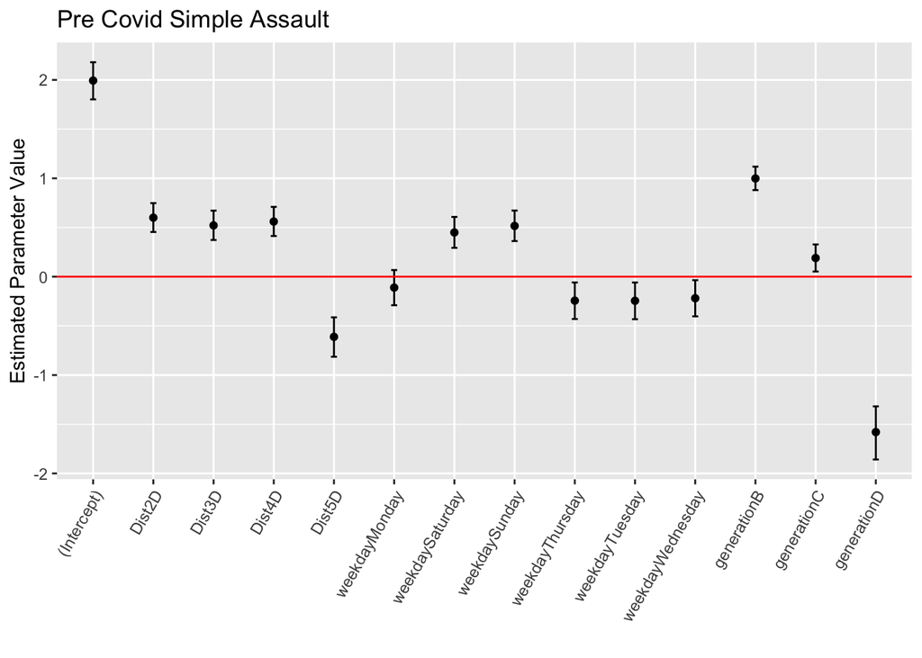

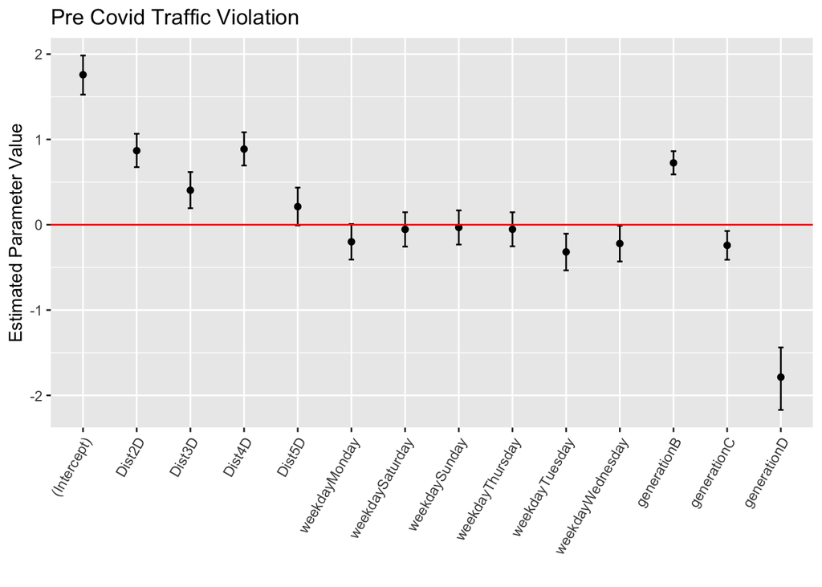

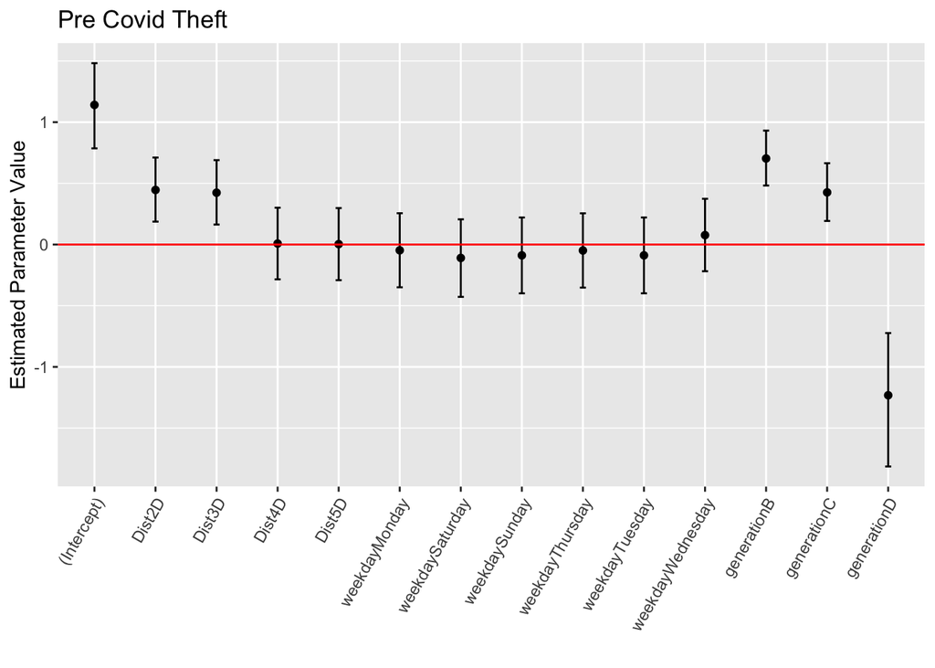

Post-Covid

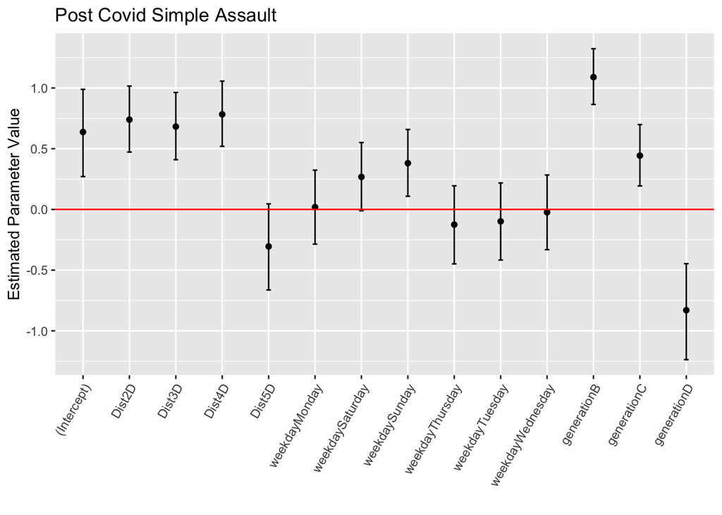